# Sensitivity and Specificity

Phil Li

May 2, 2016

## Readings

*APM*

- *Chapter 5 Measuring Performance in Regression Models* (esp. *5.2 The Variance Bias Trade-Off*) (5 pages)
- *Chapter 11 Measuring Performance in Classification Models* (~20 pages)
- *Chapter 7.4 K-Nearest Neighbors (regression)* (2 pages)
- *Chapter 13.5 K-Nearest Neighbors (classification)* (3 pages)

## EXERCISE 1: Resampling

`x` is a random variable. We want to not only know what the `mean(x)` is but want to calculate the uncertainty of `mean(x)`. Measuring the uncertainty requires repeated measurements of `mean(x)`.

- Calculate the mean of `x`.
- Calculate the `sd( mean(x) )` using the **using 10-fold cross-validation**. Create your own folds, show your work. (An example is for the Bootstrap is given as a hint. )

```r
set.seed(1)
x <- runif(20,1,20)  # from a uniform dist, select 20 numbers from 1 to 20
k <- 10

# CROSS-VALIDATION
sd_cv <- sapply(1:k, function(i) sample(x,size=length(x)/k*(k-1),replace=FALSE) %>% mean ) %>% sd


# BOOTSTRAP (EXAMPLE)
sd_boot <- sapply(1:k, function(i) sample(x,replace=TRUE) %>% mean ) %>% sd # implies n = 20
```

- sd_cv is: 0.4399292
- sd_boot is: 1.537188

# Exercise 2: Binomial Metrics

Here’s a really simple Model of Versicolor iris based on the **iris** data :

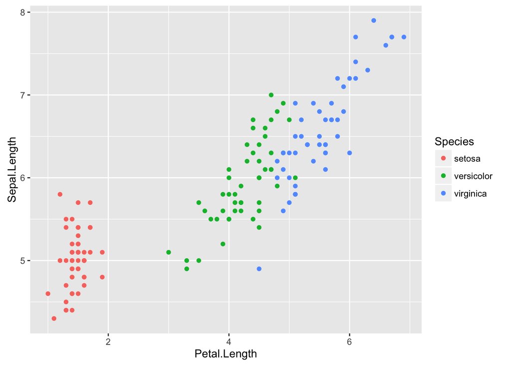

```r
set.seed(1)
data(iris)

qplot( data=iris, x=Petal.Length, y=Sepal.Length, color=Species )
```

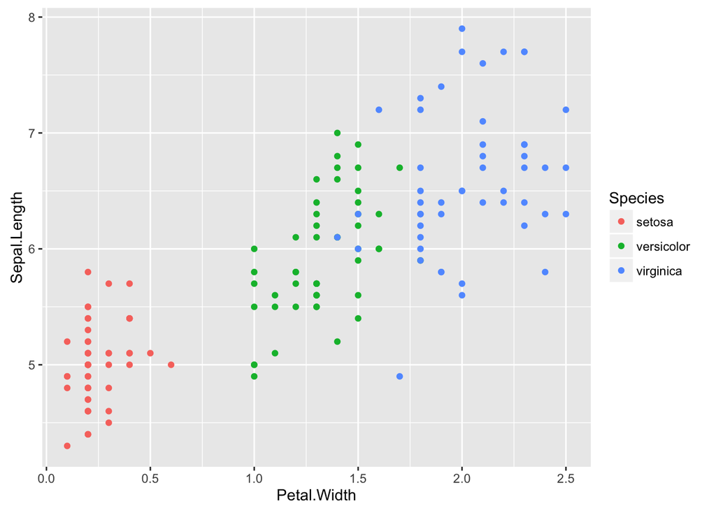

```r
qplot( data=iris, x=Petal.Width, y=Sepal.Length, color=Species )
```

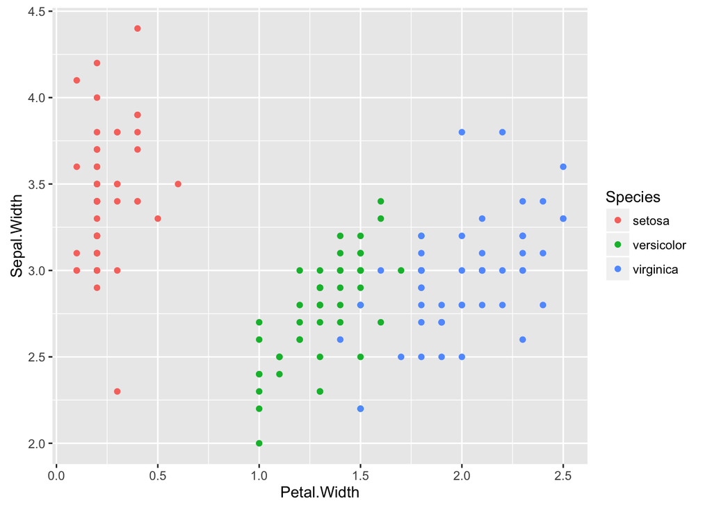

```r
qplot( data=iris, x=Petal.Width, y=Sepal.Width, color=Species )
```

```r
# Create Dependent Variable
iris$Versicolor <-
  ifelse( iris$Species == 'versicolor', "versicolor", "other" ) %>% as.factor
iris$Species = NULL

wh <- sample.int( nrow(iris), size=nrow(iris)/2 )  # splitting data set into two
train <- iris[ wh,]
test <- iris[ -wh, ]


fit.glm <- glm( Versicolor ~ . - Sepal.Length, data=train, family=binomial )
```

Use the models to and write functions to calculate:

- Prevalence
- Accuracy
- Error Rate / Misclassification Rate
- True Positive Rate
- False Positive Rate
- True Negative Rate
- False Negative Rate
- Sensitivity
- Specificity
- Recall
- Precision

The functions should take two logical vectors of the same length, `y` and `yhat`

```r
prevalence = function(y,yhat)
  ifelse(y,1,0) %>% mean    # yhat is not necessary here

accuracy = function(y,yhat)
  ifelse(yhat==y,1,0) %>% mean

error_rate = function(y,yhat)
  ifelse(yhat!=y,1,0) %>% mean

tpr = function(y,yhat)
  sum(y & yhat) / # TP
  sum(y)          # P

#fpr = ..      # See Example

tnr = function(y,yhat)
  sum(!y & !yhat) / # TN
  sum(!y)          # N

sensitivity = tpr
specificity = tnr
recall = tpr
precision = tpr

# EXAMPLE: fpr
# The FPR is THE NUMBER OF FALSE POSITIVES / NEGATIVES (TN+FP)

threshold = 0.5
y = test$Versicolor == 'versicolor'
yhat = predict(fit.glm, test, type="response") > threshold  # predict yields probability

fpr = function(y,yhat)
  sum(y & (y != yhat) ) / # FP
  sum(! y)                # N

prevalence(y,yhat)
```

```
## [1] 0.2933333
```

```r
accuracy(y,yhat)
```

```
## [1] 0.7333333
```

```r
error_rate(y,yhat)
```

```
## [1] 0.2666667
```

```r
tpr(y,yhat)
```

```
## [1] 0.5454545
```

```r
fpr(y,yhat)
```

```
## [1] 0.1886792
```

```r
tnr(y,yhat)
```

```
## [1] 0.8113208
```

- What is wrong with the modeling approach used?

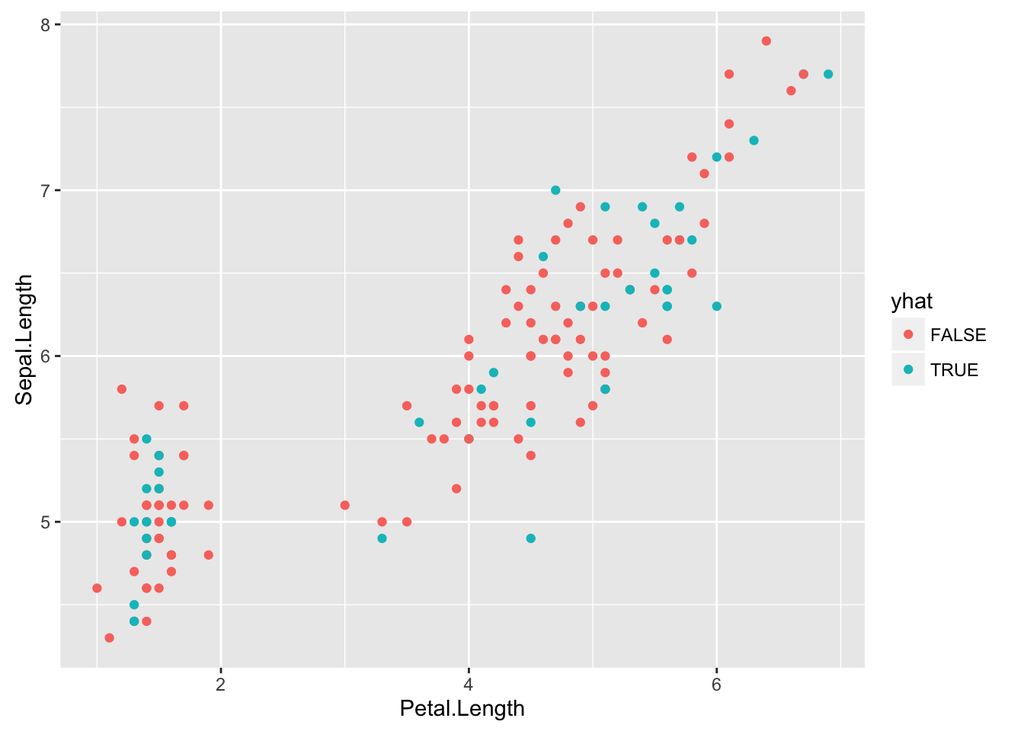

```r
# fit.glm is a poor model for versicolor.  It yields decent performance for true negatives,
# but is otherwise mediocre at best.
iris$yhat <- yhat
qplot( data=iris, x=Petal.Length, y=Sepal.Length, color=yhat )
```

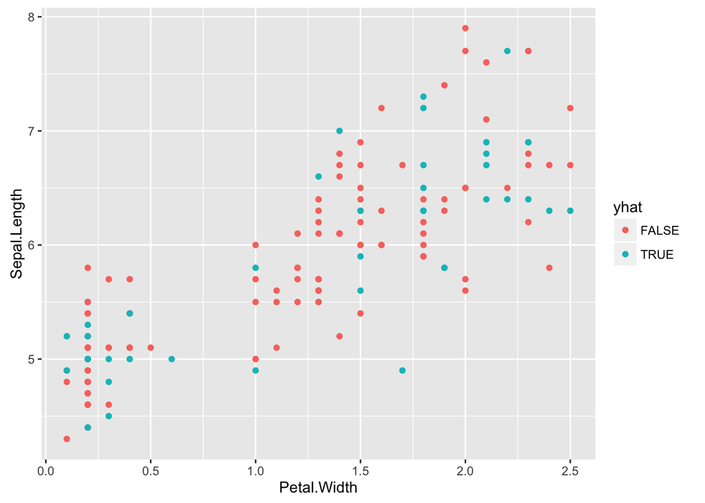

```r
qplot( data=iris, x=Petal.Width, y=Sepal.Length, color=yhat )
```

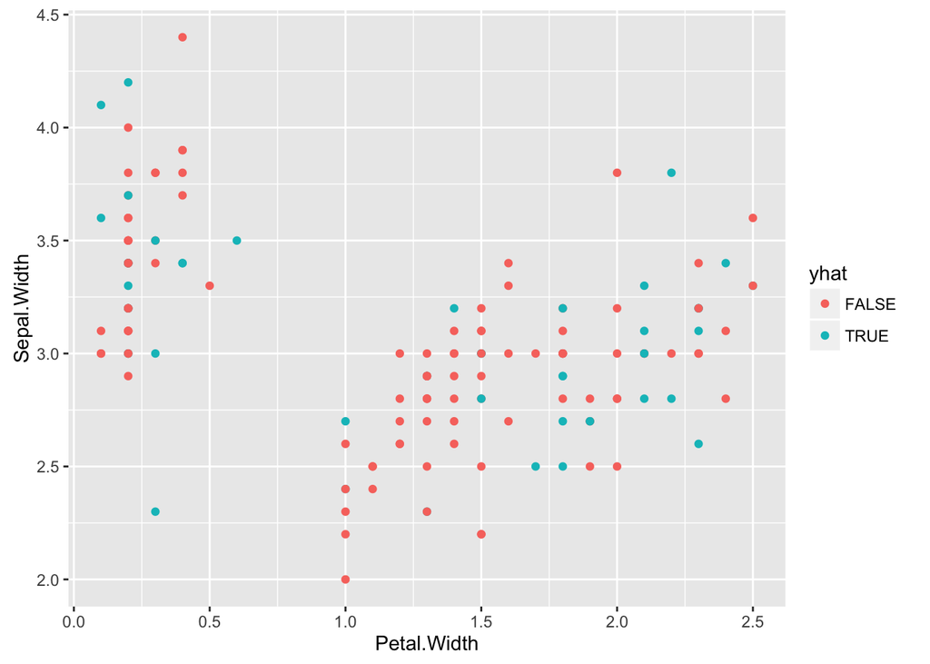

```r
qplot( data=iris, x=Petal.Width, y=Sepal.Width, color=yhat )
```

```r
# You can do much better across all metrics by noticing that Petal.Length of versicolor
# falls almost perfectly within a narrow range between 3 and 5, regardless of what the other
# factors are.  (Refer to first three graphs above.)
test_versicolor <- subset(test, Versicolor == 'versicolor')
versicolor_petal_length_max <- max(test_versicolor$Petal.Length)
versicolor_petal_length_min <- min(test_versicolor$Petal.Length)
yhat_better <- (versicolor_petal_length_min <= test$Petal.Length &
                        test$Petal.Length <= versicolor_petal_length_max)

accuracy(y,yhat_better)
```

```
## [1] 0.92
```

```r
error_rate(y,yhat_better)
```

```
## [1] 0.08
```

```r
tpr(y,yhat_better)
```

```
## [1] 1
```

```r
fpr(y,yhat_better)
```

```
## [1] 0
```

```r
tnr(y,yhat_better)
```

```
## [1] 0.8867925
```